# **Problem Statement**

## 6.7 - Model 4 - Add dropout layer

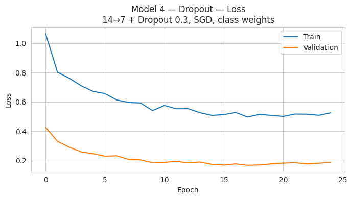

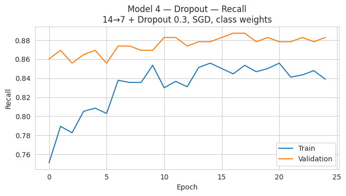

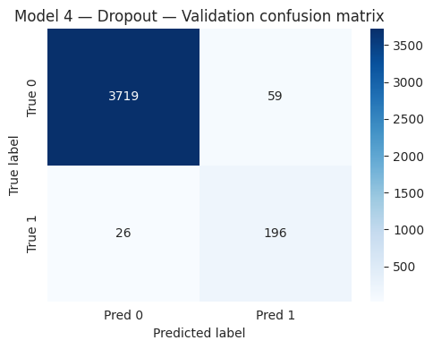

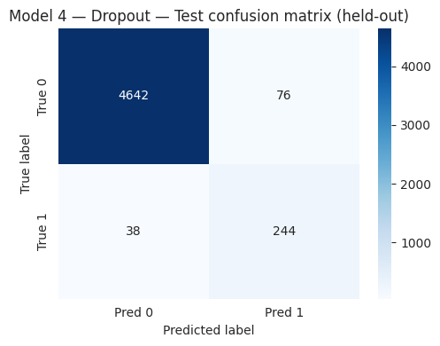

```
Training time: 19.4s
Validation maintenance cost: $4,275,000 | Cost efficiency: 0.7789
```

|  | Accuracy | Recall | Precision | F1 | Maintenance_Cost | Cost_Efficiency |
| --- | --- | --- | --- | --- | --- | --- |
| Model 4 — Dropout | 0.977125 | 0.897523 | 0.74347 | 0.813265 | 16970000 | 0.784915 |

|  | Accuracy | Recall | Precision | F1 | Maintenance_Cost | Cost_Efficiency |
| --- | --- | --- | --- | --- | --- | --- |
| Model 4 — Dropout | 0.97875 | 0.882883 | 0.768627 | 0.821803 | 4275000 | 0.778947 |

```python
model_4 = Sequential([
    Input(shape=(X_train.shape[1],)),
    Dense(14, activation='relu'),
    Dropout(0.3),
    Dense(7, activation='relu'),
    Dropout(0.3),
    Dense(1, activation='sigmoid'),
])
model_4.compile(loss='binary_crossentropy', optimizer=SGD(), metrics=['Recall'])
model_4, _ = train_and_evaluate(
    'Model 4 — Dropout',
    model_4,
    config_note='14→7 + Dropout 0.3, SGD, class weights',
)
```

**Observation**

- Model 4 adds dropout (0.3) to the two-hidden-layer architecture.
- Dropout may reduce overfitting; compare validation cost metrics with Model 1.

## 6.8 - Model 5 - Train without class weights

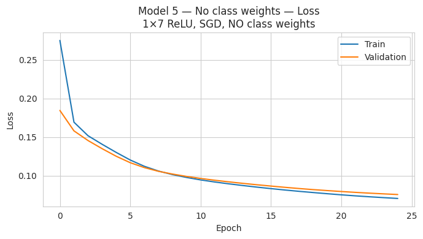

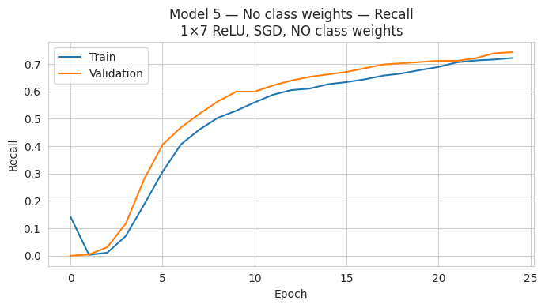

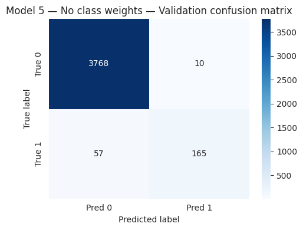

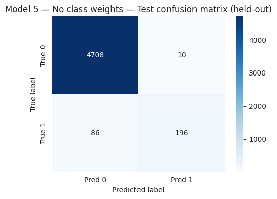

```
Training time: 18.3s
Validation maintenance cost: $4,805,000 | Cost efficiency: 0.6930
```

|  | Accuracy | Recall | Precision | F1 | Maintenance_Cost | Cost_Efficiency |
| --- | --- | --- | --- | --- | --- | --- |
| Model 5 — No class weights | 0.983313 | 0.717342 | 0.975498 | 0.826736 | 19675000 | 0.677001 |

|  | Accuracy | Recall | Precision | F1 | Maintenance_Cost | Cost_Efficiency |
| --- | --- | --- | --- | --- | --- | --- |
| Model 5 — No class weights | 0.98325 | 0.743243 | 0.942857 | 0.831234 | 4805000 | 0.693028 |

```python
model_5 = Sequential([
    Input(shape=(X_train.shape[1],)),
    Dense(7, activation='relu'),
    Dense(1, activation='sigmoid'),
])
model_5.compile(loss='binary_crossentropy', optimizer=SGD(), metrics=['Recall'])
model_5, _ = train_and_evaluate(
    'Model 5 — No class weights',
    model_5,
    use_class_weight=False,
    config_note='1×7 ReLU, SGD, NO class weights',
)
```

**Observation**

- Model 5 is the baseline architecture trained without class weights.
- Maintenance cost on validation typically increases when failures are under-detected.

## 6.9 - Model 6 - Adam with dropout and two hidden layers

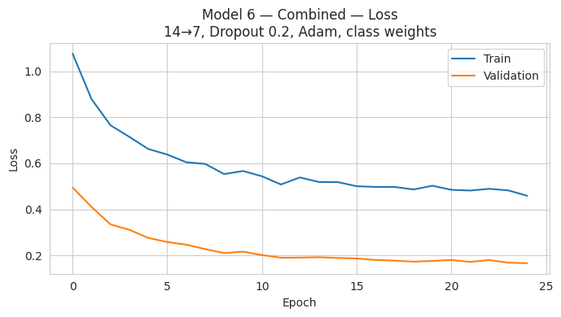

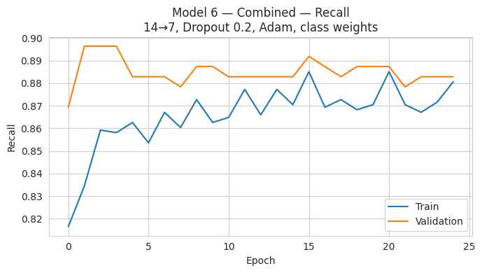

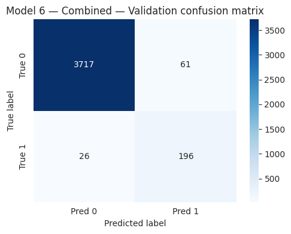

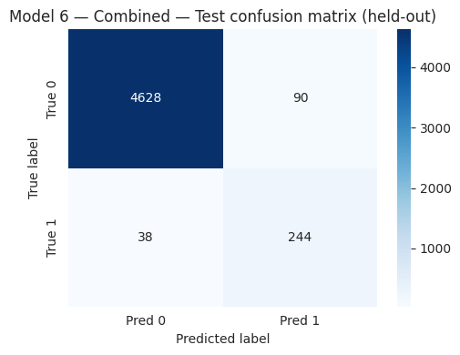

```
Training time: 21.0s
Validation maintenance cost: $4,285,000 | Cost efficiency: 0.7771
```

|  | Accuracy | Recall | Precision | F1 | Maintenance_Cost | Cost_Efficiency |
| --- | --- | --- | --- | --- | --- | --- |
| Model 6 — Combined | 0.979 | 0.898649 | 0.764368 | 0.826087 | 16800000 | 0.792857 |

|  | Accuracy | Recall | Precision | F1 | Maintenance_Cost | Cost_Efficiency |
| --- | --- | --- | --- | --- | --- | --- |
| Model 6 — Combined | 0.97825 | 0.882883 | 0.762646 | 0.818372 | 4285000 | 0.77713 |

```python
model_6 = Sequential([
    Input(shape=(X_train.shape[1],)),
    Dense(14, activation='relu'),
    Dropout(0.2),
    Dense(7, activation='relu'),
    Dropout(0.2),
    Dense(1, activation='sigmoid'),
])
model_6.compile(loss='binary_crossentropy', optimizer=Adam(learning_rate=0.0005), metrics=['Recall'])
model_6, _ = train_and_evaluate(
    'Model 6 — Combined',
    model_6,
    config_note='14→7, Dropout 0.2, Adam, class weights',
)
```

**Observation**

- Model 6 combines Adam, dropout, and two hidden layers with class weights.
- Compare validation cost efficiency with Models 3 and 4.

## 6.10 - Model 7 - Deep network with Adam and dropout

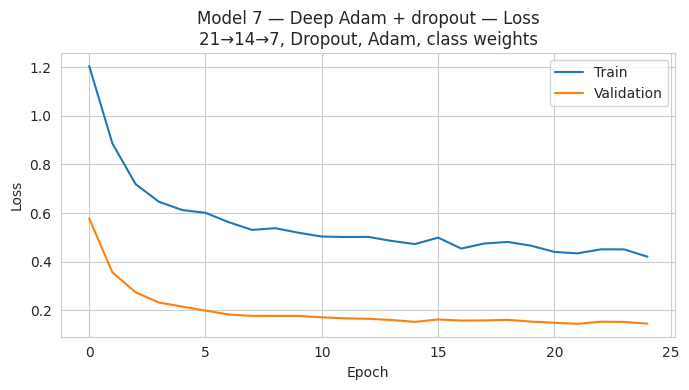

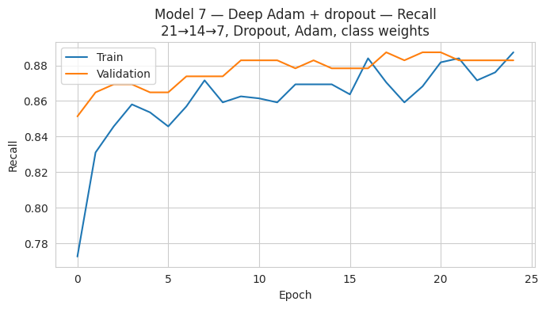

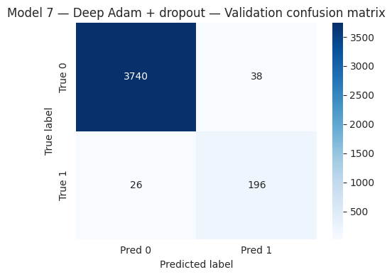

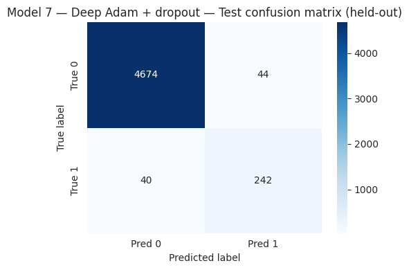

```
Training time: 21.6s
Validation maintenance cost: $4,170,000 | Cost efficiency: 0.7986
```

|  | Accuracy | Recall | Precision | F1 | Maintenance_Cost | Cost_Efficiency |
| --- | --- | --- | --- | --- | --- | --- |
| Model 7 — Deep Adam + dropout | 0.986313 | 0.900901 | 0.859291 | 0.879604 | 16175000 | 0.823493 |

|  | Accuracy | Recall | Precision | F1 | Maintenance_Cost | Cost_Efficiency |
| --- | --- | --- | --- | --- | --- | --- |
| Model 7 — Deep Adam + dropout | 0.984 | 0.882883 | 0.837607 | 0.859649 | 4170000 | 0.798561 |

```python
model_7 = Sequential([
    Input(shape=(X_train.shape[1],)),
    Dense(21, activation='relu'),
    Dropout(0.25),
    Dense(14, activation='relu'),
    Dropout(0.25),
    Dense(7, activation='relu'),
    Dense(1, activation='sigmoid'),
])
model_7.compile(loss='binary_crossentropy', optimizer=Adam(learning_rate=0.0005), metrics=['Recall'])
model_7, _ = train_and_evaluate(
    'Model 7 — Deep Adam + dropout',
    model_7,
    config_note='21→14→7, Dropout, Adam, class weights',
)
```

**Observation**

- Model 7 uses three hidden layers with Adam and dropout.
- Compare validation maintenance cost and cost efficiency across all models.

# 7 - Model Performance Comparison and Final Model Selection

```
=== Training metrics ===
```

|  | Accuracy | Recall | Precision | F1 | Maintenance_Cost | Cost_Efficiency |
| --- | --- | --- | --- | --- | --- | --- |
| Model 0 — Baseline | 0.945063 | 0.876126 | 0.502909 | 0.639014 | 19915000 | 0.668843 |
| Model 1 — 2 hidden layers | 0.981875 | 0.916667 | 0.790291 | 0.848801 | 16250000 | 0.819692 |
| Model 2 — 3 hidden layers | 0.987688 | 0.924550 | 0.863302 | 0.892877 | 15645000 | 0.851390 |
| Model 3 — Adam optimizer | 0.962500 | 0.904279 | 0.609256 | 0.728015 | 18020000 | 0.739179 |
| Model 4 — Dropout | 0.977125 | 0.897523 | 0.743470 | 0.813265 | 16970000 | 0.784915 |
| Model 5 — No class weights | 0.983313 | 0.717342 | 0.975498 | 0.826736 | 19675000 | 0.677001 |
| Model 6 — Combined | 0.979000 | 0.898649 | 0.764368 | 0.826087 | 16800000 | 0.792857 |
| Model 7 — Deep Adam + dropout | 0.986313 | 0.900901 | 0.859291 | 0.879604 | 16175000 | 0.823493 |

```
=== Validation metrics (sorted by cost efficiency) ===
```

|  | Accuracy | Recall | Precision | F1 | Maintenance_Cost | Cost_Efficiency |
| --- | --- | --- | --- | --- | --- | --- |
| Model 7 — Deep Adam + dropout | 0.98400 | 0.882883 | 0.837607 | 0.859649 | 4170000 | 0.798561 |
| Model 2 — 3 hidden layers | 0.98375 | 0.873874 | 0.839827 | 0.856512 | 4215000 | 0.790036 |
| Model 1 — 2 hidden layers | 0.97900 | 0.891892 | 0.767442 | 0.825000 | 4230000 | 0.787234 |
| Model 4 — Dropout | 0.97875 | 0.882883 | 0.768627 | 0.821803 | 4275000 | 0.778947 |
| Model 6 — Combined | 0.97825 | 0.882883 | 0.762646 | 0.818372 | 4285000 | 0.777130 |
| Model 3 — Adam optimizer | 0.96200 | 0.873874 | 0.610063 | 0.718519 | 4650000 | 0.716129 |
| Model 5 — No class weights | 0.98325 | 0.743243 | 0.942857 | 0.831234 | 4805000 | 0.693028 |
| Model 0 — Baseline | 0.94750 | 0.878378 | 0.515873 | 0.650000 | 4920000 | 0.676829 |

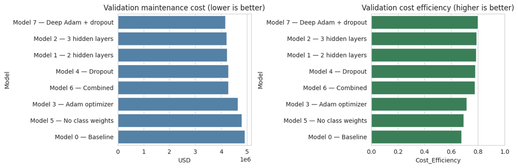

```python
train_df = pd.concat(results_train.values(), axis=0)
val_df = pd.concat(results_val.values(), axis=0)
test_df = pd.concat(results_test.values(), axis=0)

print('=== Training metrics ===')
display(train_df)

print('=== Validation metrics (sorted by cost efficiency) ===')
val_sorted = val_df.sort_values(
    ['Cost_Efficiency', 'Maintenance_Cost'],
    ascending=[False, True],
)
display(val_sorted)

# Visual: validation maintenance cost by model
plot_df = val_sorted.reset_index().rename(columns={'index': 'Model'})
fig, axes = plt.subplots(1, 2, figsize=(12, 4))
sns.barplot(data=plot_df, x='Maintenance_Cost', y='Model', ax=axes[0], color='steelblue')
axes[0].set_title('Validation maintenance cost (lower is better)')
axes[0].set_xlabel('USD')
sns.barplot(data=plot_df, x='Cost_Efficiency', y='Model', ax=axes[1], color='seagreen')
axes[1].set_title('Validation cost efficiency (higher is better)')
axes[1].set_xlim(0, 1)
plt.tight_layout()
plt.show()
```

```python
# --- Step 1: Pick architecture by validation dollars (not recall) ---
best_row = val_df.sort_values(
    ['Cost_Efficiency', 'Maintenance_Cost', 'Recall'],
    ascending=[False, True, False],
).iloc[0]
best_name = best_row.name
print('Selected architecture (validation cost efficiency):', best_name)
display(best_row.to_frame().T)

model_lookup = {
    'Model 0 — Baseline': model_0,
    'Model 1 — 2 hidden layers': model_1,
    'Model 2 — 3 hidden layers': model_2,
    'Model 3 — Adam optimizer': model_3,
    'Model 4 — Dropout': model_4,
    'Model 5 — No class weights': model_5,
    'Model 6 — Combined': model_6,
    'Model 7 — Deep Adam + dropout': model_7,
}
best_model = model_lookup[best_name]
```

```
Selected architecture (validation cost efficiency): Model 7 — Deep Adam + dropout
```

|  | Accuracy | Recall | Precision | F1 | Maintenance_Cost | Cost_Efficiency |
| --- | --- | --- | --- | --- | --- | --- |
| Model 7 — Deep Adam + dropout | 0.984 | 0.882883 | 0.837607 | 0.859649 | 4170000.0 | 0.798561 |

## 7.1 - Tune classification threshold on validation data

|  | threshold | Maintenance_Cost | Cost_Efficiency | Recall | FN | FP | TP |
| --- | --- | --- | --- | --- | --- | --- | --- |
| 11 | 0.65 | 4080000 | 0.816176 | 0.882883 | 26 | 20 | 196 |
| 12 | 0.70 | 4100000 | 0.812195 | 0.873874 | 28 | 14 | 194 |
| 10 | 0.60 | 4110000 | 0.810219 | 0.882883 | 26 | 26 | 196 |
| 13 | 0.75 | 4110000 | 0.810219 | 0.869369 | 29 | 11 | 193 |
| 14 | 0.80 | 4115000 | 0.809235 | 0.864865 | 30 | 7 | 192 |
| 9 | 0.55 | 4155000 | 0.801444 | 0.882883 | 26 | 35 | 196 |
| 15 | 0.85 | 4160000 | 0.800481 | 0.855856 | 32 | 6 | 190 |
| 7 | 0.45 | 4165000 | 0.799520 | 0.887387 | 25 | 42 | 197 |
| 8 | 0.50 | 4170000 | 0.798561 | 0.882883 | 26 | 38 | 196 |
| 16 | 0.90 | 4220000 | 0.789100 | 0.842342 | 35 | 3 | 187 |

```
Optimal validation threshold: 0.65
Validation maintenance cost at best threshold: $4,080,000
Validation cost efficiency: 0.8162
```

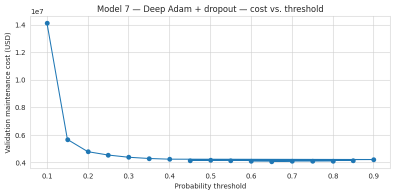

```python
threshold_grid = np.round(np.arange(0.10, 0.91, 0.05), 2)
threshold_rows = []

for t in threshold_grid:
    perf, cm = model_performance(best_model, X_val, y_val, threshold=float(t), label=f't={t}')
    threshold_rows.append({
        'threshold': t,
        'Maintenance_Cost': perf['Maintenance_Cost'].iloc[0],
        'Cost_Efficiency': perf['Cost_Efficiency'].iloc[0],
        'Recall': perf['Recall'].iloc[0],
        'FN': int(cm[1, 0]),
        'FP': int(cm[0, 1]),
        'TP': int(cm[1, 1]),
    })

threshold_df = pd.DataFrame(threshold_rows).sort_values(
    ['Cost_Efficiency', 'Maintenance_Cost'], ascending=[False, True]
)
display(threshold_df.head(10))

best_threshold_row = threshold_df.iloc[0]
BEST_THRESHOLD = float(best_threshold_row['threshold'])
print(f'Optimal validation threshold: {BEST_THRESHOLD}')
print(f"Validation maintenance cost at best threshold: ${int(best_threshold_row['Maintenance_Cost']):,}")
print(f"Validation cost efficiency: {best_threshold_row['Cost_Efficiency']:.4f}")

plt.figure(figsize=(8, 4))
plt.plot(threshold_df['threshold'], threshold_df['Maintenance_Cost'], marker='o')
plt.xlabel('Probability threshold')
plt.ylabel('Validation maintenance cost (USD)')
plt.title(f'{best_name} — cost vs. threshold')
plt.tight_layout()
plt.show()
```

```
=== Final validation performance (tuned threshold) ===
```

|  | Accuracy | Recall | Precision | F1 | Maintenance_Cost | Cost_Efficiency |
| --- | --- | --- | --- | --- | --- | --- |
| Model 7 — Deep Adam + dropout (val, tuned) | 0.9885 | 0.882883 | 0.907407 | 0.894977 | 4080000 | 0.816176 |

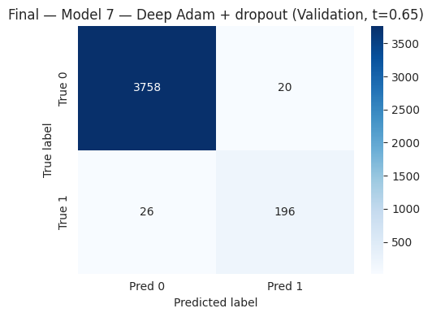

```
=== Final test performance (held-out; evaluate once) ===
```

|  | Accuracy | Recall | Precision | F1 | Maintenance_Cost | Cost_Efficiency |
| --- | --- | --- | --- | --- | --- | --- |
| Model 7 — Deep Adam + dropout (test) | 0.9856 | 0.843972 | 0.894737 | 0.868613 | 5470000 | 0.773309 |

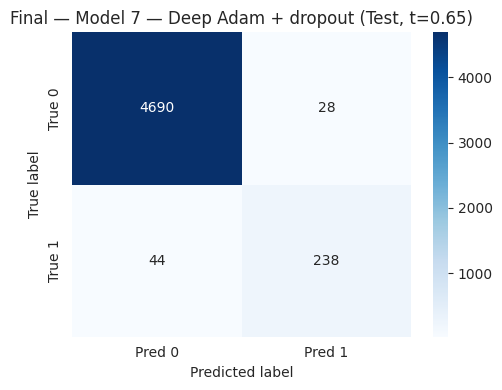

```
Test confusion counts — TP: 238 FN: 44 FP: 28 TN: 4690
Test maintenance cost: $5,470,000
Test cost efficiency: 0.7733
```

```python
# --- Step 2: One-time held-out test evaluation at dollar-optimal threshold ---
val_final_perf, val_final_cm = model_performance(
    best_model, X_val, y_val, threshold=BEST_THRESHOLD, label=best_name + ' (val, tuned)'
)
final_test_perf, final_cm = model_performance(
    best_model, X_test, y_test, threshold=BEST_THRESHOLD, label=best_name + ' (test)'
)

print('=== Final validation performance (tuned threshold) ===')
display(val_final_perf)
show_confusion(val_final_cm, f'Final — {best_name} (Validation, t={BEST_THRESHOLD})')

print('=== Final test performance (held-out; evaluate once) ===')
display(final_test_perf)
show_confusion(final_cm, f'Final — {best_name} (Test, t={BEST_THRESHOLD})')

tn, fp, fn, tp = final_cm.ravel()
print('Test confusion counts — TP:', tp, 'FN:', fn, 'FP:', fp, 'TN:', tn)
print('Test maintenance cost: $' + f"{int(final_test_perf['Maintenance_Cost'].iloc[0]):,}")
print('Test cost efficiency:', round(final_test_perf['Cost_Efficiency'].iloc[0], 4))
```

**Observation**

- The final model is selected using validation cost efficiency and maintenance cost.
- The probability threshold is tuned on the validation set.
- The test set is used once for final evaluation at the selected threshold.

# 8 - Actionable Insights and Recommendations

**Actionable insights**

1. Predictive maintenance models should be compared using maintenance cost and cost efficiency on validation data, in addition to recall.
2. Class weights help detect rare failures and reduce replacement costs from false negatives.
3. Model depth, dropout, and the Adam optimizer can improve validation cost efficiency; the final architecture should be chosen based on validation metrics.
4. Tuning the classification threshold on validation data can further reduce maintenance cost before deployment.

**Business recommendations**

1. Deploy the selected model with the tuned probability threshold in maintenance workflows.
2. Monitor TP, FN, and FP counts and translate them into maintenance cost for management reporting.
3. Retrain the model periodically as new sensor data and failure labels become available.
4. Focus instrumentation quality on sensors most correlated with failures identified during EDA.